# ML

## Nauczymy komputer rozpoznawać czy podany ciąg jest posortowany rosnąco.

Na początek kod generujący zbiory danych.

```r
library(dplyr)
library(caret)
library(rpart)
library(rpart.plot)
library(h2o)
library(ggplot2)
library(ROCR)
## Funkcja generuje macierz o N wierwszach i M kolumnach wypeĹ‚nionÄ… losowo elementami ze zbioru x
prepare.dataset <- function(M,N,x)
{

  dataset <- matrix(nrow = N, ncol = M, sample(x,N*M,replace = TRUE), byrow = TRUE )

  dataset <- data.frame(dataset)

  y <- apply( dataset, MARGIN = 1
              , FUN = function(row)
              {
                !any((row[-1] - row[-M]) < 0)
              }
  )

  dataset$y <- y
  return(dataset)
}
```

Generujemy:

Dane stanowi 5 kolumn z kolejnymi liczbami w ciągu oraz ostatnia kolumna mówiąca czy ten ciąg jest posortowany.

```r
set.seed(1123)
simple.dataset <- prepare.dataset(5, 20000,1:5)
```

```r
head(simple.dataset)
```

|  | X1 | X2 | X3 | X4 | X5 | y |
| --- | --- | --- | --- | --- | --- | --- |
| 1 | 4 | 5 | 5 | 3 | 5 | FALSE |
| 2 | 1 | 1 | 4 | 5 | 2 | FALSE |
| 3 | 3 | 4 | 3 | 3 | 5 | FALSE |
| 4 | 3 | 4 | 2 | 1 | 3 | FALSE |
| 5 | 4 | 2 | 3 | 3 | 3 | FALSE |
| 6 | 5 | 4 | 3 | 2 | 4 | FALSE |

### Wykorzystamy prosty algorytm, którego wynik można przedstawić w postaci drzewa decyzyjnego:

```r
tree.model.simple <- rpart(y~., data = simple.dataset)
predicted.tree <- predict( tree.model.simple, simple.dataset )
```

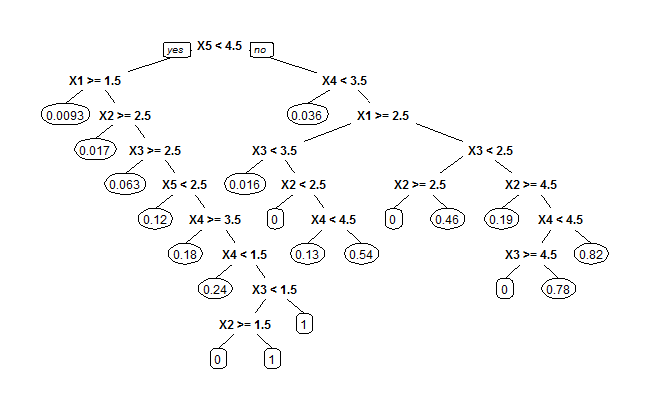

```r
prp(tree.model.simple)
```

### Nasz algorytm zwraca szanse, że dany ciąg jest posortowany.

```r
head(predicted.tree,20)
```

```
          1           2           3           4           5           6
0.036241045 0.063063063 0.036241045 0.009347978 0.009347978 0.009347978
          7           8           9          10          11          12
0.036241045 0.009347978 0.009347978 0.017268446 0.009347978 0.009347978
         13          14          15          16          17          18
0.009347978 0.017268446 0.009347978 0.820689655 0.009347978 0.009347978
         19          20
0.009347978 0.036241045
```

### Idealna byłaby sytuacja, gdyby zwracał zawsze 1 gdy ciag posortowany i zawsze 0 gdy ciąg jest nie posortowany.

Równie wspaniale gdyby istniała taka liczba pomiędzy zero i jeden, że gdy ciąg jest posortowany to algorytm zwraca szanse powyżej tej liczby, a jak jak nie posrtowany to poniżej.

[figure not shown]

Od prawdopodobieństw do decyzji przechodzimi poprzez wybranie punktu odcięcią (cutoff).

```r
## wybieramy najlepszy Cutoff z punktu widzenia AC
pred <- ROCR::prediction(predicted.tree,simple.dataset$y)
perf <- performance(pred,"acc")
perf.F <- performance(pred,"f")
best.acc.cutoff.tree <- perf@x.values[[1]][which.max( perf@y.values[[1]] )]
best.F.cutoff.tree <- perf.F@x.values[[1]][which.max( perf.F@y.values[[1]] )]
```

```r
print(paste('cutoff',round(best.acc.cutoff.tree,3)))
```

```
[1] "cutoff 0.537"
```

```r
labels.tree <- predicted.tree >= best.acc.cutoff.tree
caret::confusionMatrix(table(labels.tree,simple.dataset$y),'TRUE')
```

```
Confusion Matrix and Statistics


labels.tree FALSE  TRUE
      FALSE 19105   437
      TRUE    106   352

               Accuracy : 0.9728
                 95% CI : (0.9705, 0.9751)
    No Information Rate : 0.9606
    P-Value [Acc > NIR] : < 2.2e-16

                  Kappa : 0.5516
 Mcnemar's Test P-Value : < 2.2e-16

            Sensitivity : 0.44613
            Specificity : 0.99448
         Pos Pred Value : 0.76856
         Neg Pred Value : 0.97764
             Prevalence : 0.03945
         Detection Rate : 0.01760
   Detection Prevalence : 0.02290
      Balanced Accuracy : 0.72031

       'Positive' Class : TRUE
```

```r
print(paste('cutoff',round(best.F.cutoff.tree,3)))
```

```
[1] "cutoff 0.461"
```

```r
labels.tree <- predicted.tree >= best.F.cutoff.tree
caret::confusionMatrix(table(labels.tree,simple.dataset$y),'TRUE')
```

```
Confusion Matrix and Statistics


labels.tree FALSE  TRUE
      FALSE 19043   384
      TRUE    168   405

               Accuracy : 0.9724
                 95% CI : (0.97, 0.9746)
    No Information Rate : 0.9606
    P-Value [Acc > NIR] : < 2.2e-16

                  Kappa : 0.5808
 Mcnemar's Test P-Value : < 2.2e-16

            Sensitivity : 0.51331
            Specificity : 0.99126
         Pos Pred Value : 0.70681
         Neg Pred Value : 0.98023
             Prevalence : 0.03945
         Detection Rate : 0.02025
   Detection Prevalence : 0.02865
      Balanced Accuracy : 0.75228

       'Positive' Class : TRUE
```

### Teraz na tych samych danych nauczymy maszynę korzystając z dużo bardziej złożonego algorytmu.

```r
h2o.init()
simple.dataset.hex <- as.h2o(simple.dataset)

rf.model <- h2o.randomForest(x = paste0('X',1:5)
                             ,y = 'y'
                             ,training_frame = simple.dataset.hex
                             )

predicted.rf.hex <- predict(rf.model,simple.dataset.hex)
predicted.rf <- as.data.frame(predicted.rf.hex)[,'TRUE.']
```

```r
best.acc.cutoff.rf
```

```
[1] 0.84
```

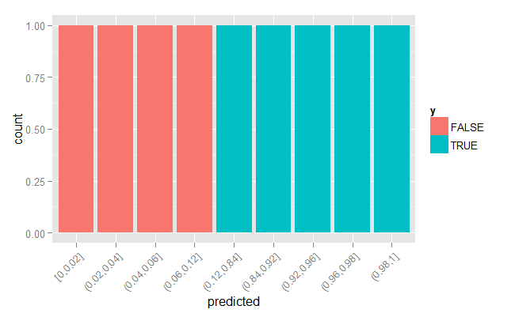

```r
cut.rf.10 <- unique(predicted.rf)#unique(quantile(predicted.rf, probs = seq(0,1,0.001)))
plot.df <- data.frame(predicted = cut(predicted.rf,cut.rf.10,right = TRUE,include.lowest = TRUE)
                      , y = simple.dataset$y)
ggplot(data = plot.df) + geom_bar(aes(x = predicted, fill = y ),position = 'fill') +  theme(axis.text.x=element_text(angle=45, hjust=1))
```

### A teraz zabijemy nasze OBA modele :(

Ciągi składają się z liczb z przedziału od 6 do 10. Modele uczyły się na ciągach składających się z liczb od 1 do 5.

```r
dead.set <- prepare.dataset(5, 20000,6:10)
```

```r
predicted.tree <- predict( tree.model.simple, dead.set )
labels.tree <- predicted.tree >= best.acc.cutoff.tree
table(labels.tree,real = dead.set$y)
```

```
           real
labels.tree FALSE  TRUE
       TRUE 19207   793
```

```r
dead.set.hex <- as.h2o(dead.set)

predicted.rf.hex <- predict(rf.model,simple.dataset.hex)
predicted.rf <- as.data.frame(predicted.rf.hex)[,'TRUE.']


labels.rf <- predicted.rf >= best.acc.cutoff.rf
```

```r
caret::confusionMatrix( table(labels.rf,real = dead.set$y) ,positive = 'TRUE')
```

```
Confusion Matrix and Statistics

         real
labels.rf FALSE  TRUE
    FALSE 18444   767
    TRUE    763    26

               Accuracy : 0.9235
                 95% CI : (0.9197, 0.9271)
    No Information Rate : 0.9604
    P-Value [Acc > NIR] : 1.0000

                  Kappa : -0.007
 Mcnemar's Test P-Value : 0.9389

            Sensitivity : 0.03279
            Specificity : 0.96027
         Pos Pred Value : 0.03295
         Neg Pred Value : 0.96007
             Prevalence : 0.03965
         Detection Rate : 0.00130
   Detection Prevalence : 0.03945
      Balanced Accuracy : 0.49653

       'Positive' Class : TRUE
```

### Transofrmacje posiadanych danych

Do tej pory pracowaliśmy tylko na dostarczonym zestawie danych tj. ciągu kolejnych liczb.

Teraz wykonamy prostą transformację tych danych, aby uzyskać nowe informacje. Dodamy różnice pomiędzy kolejnymi liczbami w ciągu.

```r
transform.dataset <- function(dataset)
{
  nd <- dataset[,-1] - dataset[,-ncol(dataset)]
  names(nd) <- paste0('diff',1:ncol(nd))
  return(cbind(dataset, nd))
}
```

Budujemy modele, które wykorzystują nowo dodane cechy. Zwróćmy uwagę na problem wyboru cech!

```r
source.data <- simple.dataset[-ncol(simple.dataset)]
y <- simple.dataset$y
transformed.data <- transform.dataset(source.data)
head(transformed.data)
```

|  | X1 | X2 | X3 | X4 | X5 | diff1 | diff2 | diff3 | diff4 |
| --- | --- | --- | --- | --- | --- | --- | --- | --- | --- |
| 1 | 4 | 5 | 5 | 3 | 5 | 1 | 0 | -2 | 2 |
| 2 | 1 | 1 | 4 | 5 | 2 | 0 | 3 | 1 | -3 |
| 3 | 3 | 4 | 3 | 3 | 5 | 1 | -1 | 0 | 2 |
| 4 | 3 | 4 | 2 | 1 | 3 | 1 | -2 | -1 | 2 |
| 5 | 4 | 2 | 3 | 3 | 3 | -2 | 1 | 0 | 0 |
| 6 | 5 | 4 | 3 | 2 | 4 | -1 | -1 | -1 | 2 |

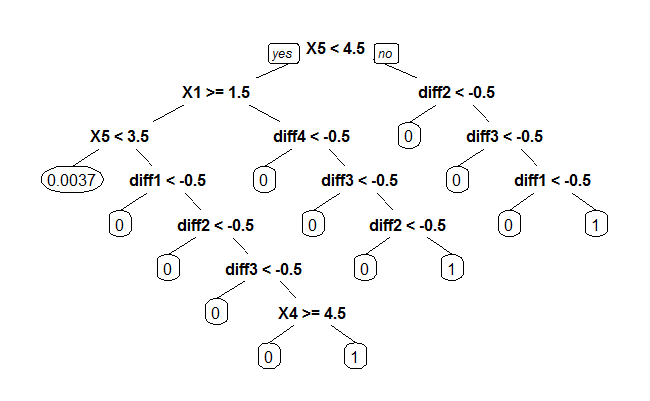

```r
tree.model.2 <- rpart(y~., data = transformed.data)
tree.model.3 <- rpart(y~diff1+diff2+diff3+diff4, data = transformed.data)
prp(tree.model.2)
```

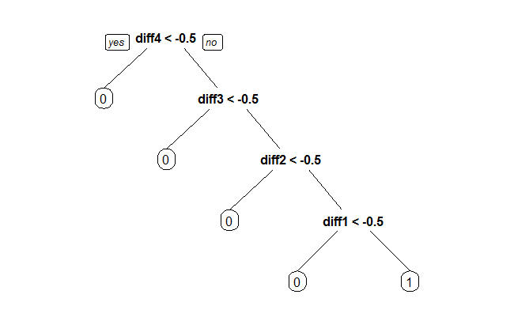

```r
prp(tree.model.3)
```

```r
predicted.tree <- predict( tree.model.2, transformed.data )
pred <- ROCR::prediction(predicted.tree,simple.dataset$y)
perf <- performance(pred,"acc")
best.acc.cutoff.tree <- perf@x.values[[1]][which.max( perf@y.values[[1]] )]
labels.tree <- predicted.tree >= best.acc.cutoff.tree
caret::confusionMatrix(table(labels.tree,simple.dataset$y))
```

```
Confusion Matrix and Statistics


labels.tree FALSE  TRUE
      FALSE 19211    36
      TRUE      0   753

               Accuracy : 0.9982
                 95% CI : (0.9975, 0.9987)
    No Information Rate : 0.9606
    P-Value [Acc > NIR] : < 2.2e-16

                  Kappa : 0.9757
 Mcnemar's Test P-Value : 5.433e-09

            Sensitivity : 1.0000
            Specificity : 0.9544
         Pos Pred Value : 0.9981
         Neg Pred Value : 1.0000
             Prevalence : 0.9606
         Detection Rate : 0.9606
   Detection Prevalence : 0.9624
      Balanced Accuracy : 0.9772

       'Positive' Class : FALSE
```

```r
dead.set.transformed <- transform.dataset(dead.set)
predicted.tree <- predict( tree.model.2, dead.set.transformed )
labels.tree <- predicted.tree >= best.acc.cutoff.tree
caret::confusionMatrix(table(Prognoza = labels.tree,REAL = dead.set$y),'TRUE')
```

```
Confusion Matrix and Statistics

        REAL
Prognoza FALSE  TRUE
   FALSE 17817     0
   TRUE   1390   793

               Accuracy : 0.9305
                 95% CI : (0.9269, 0.934)
    No Information Rate : 0.9604
    P-Value [Acc > NIR] : 1

                  Kappa : 0.5041
 Mcnemar's Test P-Value : <2e-16

            Sensitivity : 1.00000
            Specificity : 0.92763
         Pos Pred Value : 0.36326
         Neg Pred Value : 1.00000
             Prevalence : 0.03965
         Detection Rate : 0.03965
   Detection Prevalence : 0.10915
      Balanced Accuracy : 0.96382

       'Positive' Class : TRUE
```

```r
predicted.tree <- predict( tree.model.3, transformed.data )
pred <- ROCR::prediction(predicted.tree,simple.dataset$y)
perf <- performance(pred,"acc")
best.acc.cutoff.tree <- perf@x.values[[1]][which.max( perf@y.values[[1]] )]
labels.tree <- predicted.tree >= best.acc.cutoff.tree
caret::confusionMatrix(table(labels.tree,simple.dataset$y),'TRUE')
```

```
Confusion Matrix and Statistics


labels.tree FALSE  TRUE
      FALSE 19211     0
      TRUE      0   789

               Accuracy : 1
                 95% CI : (0.9998, 1)
    No Information Rate : 0.9606
    P-Value [Acc > NIR] : < 2.2e-16

                  Kappa : 1
 Mcnemar's Test P-Value : NA

            Sensitivity : 1.00000
            Specificity : 1.00000
         Pos Pred Value : 1.00000
         Neg Pred Value : 1.00000
             Prevalence : 0.03945
         Detection Rate : 0.03945
   Detection Prevalence : 0.03945
      Balanced Accuracy : 1.00000

       'Positive' Class : TRUE
```

```r
dead.set.transformed <- transform.dataset(dead.set)
predicted.tree <- predict( tree.model.3, dead.set.transformed )
labels.tree <- predicted.tree >= best.acc.cutoff.tree
caret::confusionMatrix(table(labels.tree,dead.set$y),'TRUE')
```

```
Confusion Matrix and Statistics


labels.tree FALSE  TRUE
      FALSE 19207     0
      TRUE      0   793

               Accuracy : 1
                 95% CI : (0.9998, 1)
    No Information Rate : 0.9604
    P-Value [Acc > NIR] : < 2.2e-16

                  Kappa : 1
 Mcnemar's Test P-Value : NA

            Sensitivity : 1.00000
            Specificity : 1.00000
         Pos Pred Value : 1.00000
         Neg Pred Value : 1.00000
             Prevalence : 0.03965
         Detection Rate : 0.03965
   Detection Prevalence : 0.03965
      Balanced Accuracy : 1.00000

       'Positive' Class : TRUE
```